Mini-project 1 (week 5)

# SVM & LR Classification

Eyob Gebremariam, Edgar Johnson and Christopher Krug

## Assignment research question, prediction

For this exercise were are exploring whether the 2014 school data provides evidence about anecdotal claims that schools with a higher diversity of students, i.e., a mix of white, Black, Hispanic, Native American, Asian, tend to have higher attrition rates than schools who are less diverse. Therefore, we will be classifying/identifying schools that may be at more risk of losing experienced teachers.

To explore this research question, we will use teacher experince as a surrogate variable, i.e., schools that have lower values for teacher experience will be interpreted as having higher attrition rates. Addtionally, we will create a bivariate value from the teacher experience attribute.

**NOTE:** *Given the results of lab assingment one, **we will perform a principle component analysis (PCA) on the demographic variables**. The results of that assignment indicated strong evidence of multicollinearity and this dimension reduction technique may provide more accurate logistic regression predictions.*

**SVM and Logistic Regression Modeling** *links to ansers:*

- [50 points] *Create a logistic regression model and a support vector machine model for the classification task involved with your dataset. Assess how well each model performs (use 80/20 training/testing split for your data). Adjust parameters of the models to make them more accurate. If your dataset size requires the use of stochastic gradient descent, then linear kernel only is fine to use.*
- [10 points] *Discuss the advantages of each model for each classification task. Does one type of model offer superior performance over another in terms of prediction accuracy? In terms of training time or efficiency? Explain in detail.*
- [30 points] *Use the weights from logistic regression to interpret the importance of different features for each classification task. Explain your interpretation in detail. Why do you think some variables are more important?*
- [10 points] *Look at the chosen support vectors for the classification task. Do these provide any insight into the data? Explain.*

### Import relevant libraries

```python
import os,sys
import xlrd
import math
import pandas as pd
from pandas.tools.plotting import scatter_matrix
import numpy as np
import matplotlib.pyplot as plt
plt.style.use('ggplot')
%matplotlib inline
from sklearn import decomposition
from sklearn.cross_validation import ShuffleSplit
from sklearn.cross_validation import train_test_split
from sklearn.linear_model import LogisticRegression
from sklearn import metrics as mt
from sklearn import svm
```

### Create list of files provided by OEQA

```python
directoryPath = 'oeqaProfiles'
directory = os.listdir(directoryPath)
oeqaFilesProvided = []
for file in directory:
        oeqaFilesProvided.append(file)
print ('Number of files: '+ str(len(oeqaFilesProvided)))
print (oeqaFilesProvided)
```

```
Number of files: 18
['Profiles Database 1997(Excel 5).xls', 'Profiles Database 1998.xls', 'Profiles Database 1999.xls', 'Profiles Database 2000.xls', 'Profiles Database 2001.xls', 'Profiles Database 2002.xls', 'Profiles Database 2003.xls', 'Profiles Database 2004.xls', 'Profiles Database 2005.xls', 'Profiles Database 2…
```

### Create list of years of data

```python
profileYears = []
yearsStart = int(1997)

while yearsStart < 2015:
    profileYears.append(yearsStart)
    yearsStart = yearsStart+1
print (profileYears)
```

```
[1997, 1998, 1999, 2000, 2001, 2002, 2003, 2004, 2005, 2006, 2007, 2008, 2009, 2010, 2011, 2012, 2013, 2014]
```

### Import files to dictionary of dataframes

```python
def importExcelFiles(dictionary,years,files,directory,sheetKeyword):
    count = 0
    for year in years:
        yearData = str(year)
        fileName = files[count]
        dataFrameName = sheetKeyword+yearData
        pathToFile = os.path.join(directory,fileName)
        sheetNames = pd.ExcelFile(pathToFile).sheet_names
        for sheetName in sheetNames:
            if sheetKeyword in sheetName:
                #Use print to provide user feedback
                print (fileName+" is now '"+dataFrameName+"'")
                try:
                    dictionary[dataFrameName]=pd.read_excel(pathToFile,sheetname=sheetName,header=None)
                    ## Having an error with 2005
                except:
                    pass
        count = count+1

dataFrames = {}
importExcelFiles(dataFrames,profileYears,oeqaFilesProvided,"oeqaProfiles","School")
```

```
Profiles Database 1997(Excel 5).xls is now 'School1997'
Profiles Database 1998.xls is now 'School1998'
Profiles Database 1999.xls is now 'School1999'
Profiles Database 2000.xls is now 'School2000'
Profiles Database 2001.xls is now 'School2001'
Profiles Database 2002.xls is now 'School2002'
Profiles Database 2003.xls is now 'School2003'
Profiles Database 2004.xls is now 'School2004'
Profiles Database 2005.xls is now 'School2005'
Profiles Database 2006.xls is now 'School2006'
Profiles Database 2007.xls is now 'School2007'
Profiles Database 2008.xls is now 'School2008'
Profiles Database 2009.xls is now 'School2009'
Profiles Database 2010.xls is now 'School2010'
Profiles Database 2011.xlsx is now 'School2011'
Profiles Database 2012.xlsx is now 'School2012'
Profiles Database 2013.xlsx is now 'School2013'
Profiles Database 2014.xlsx is now 'School2014'
```

### View keys for dataframes

```python
dfKeys = list(dataFrames.keys())
print (dfKeys)
```

```
['School2007', 'School2014', 'School2000', 'School1999', 'School2013', 'School1998', 'School1997', 'School2011', 'School2004', 'School2001', 'School2003', 'School2008', 'School2012', 'School2010', 'School2009', 'School2006', 'School2002']
```

### Examine raw dimensions of 2014 data

```python
school2014raw = dataFrames["School2014"]
school2014raw.shape
```

```
(1777, 207)
```

### View head of raw 2014

```python
school2014raw.head(8)
```

|  | 0 | 1 | 2 | 3 | 4 | 5 | 6 | 7 | 8 | 9 | ... | 197 | 198 | 199 | 200 | 201 | 202 | 203 | 204 | 205 | 206 |
| --- | --- | --- | --- | --- | --- | --- | --- | --- | --- | --- | --- | --- | --- | --- | --- | --- | --- | --- | --- | --- | --- |
| 0 | Rec No: | 1 | NaN | NaN | NaN | NaN | NaN | NaN | NaN | NaN | ... | NaN | NaN | NaN | NaN | NaN | NaN | NaN | NaN | NaN | NaN |
| 1 | NaN | 01C019105 | 01 | C019 | 105 | 1 | PRIMARY | ADAIR | PEAVINE | PEAVINE ELEMENTARY | ... | DNA | DNA | DNA | DNA | DNA | DNA | DNA | DNA | DNA | DNA |
| 2 | NaN | PRIMARY State Average: | NaN | NaN | NaN | NaN | NaN | NaN | NaN | NaN | ... | 43 | 80 | 15 | 50 | 25 | 77 | 37 | 81 | 25 | 87 |
| 3 | NaN | School Header | NaN | NaN | NaN | NaN | NaN | NaN | NaN | NaN | ... | NaN | NaN | NaN | NaN | NaN | NaN | NaN | NaN | NaN | NaN |
| 4 | NaN | NaN | NaN | NaN | NaN | NaN | NaN | NaN | NaN | NaN | ... | EOI - U.S. History (All Students, FAY) | NaN | EOI - Biology I (All Students, FAY) | NaN | EOI - Algebra II (All Students, FAY) | NaN | EOI - Geometry (All Students, FAY) | NaN | EOI - English III (All Students, FAY) | NaN |
| 5 | NaN | NaN | NaN | NaN | NaN | NaN | NaN | NaN | NaN | NaN | ... | Performance (%) | NaN | Performance (%) | NaN | Performance (%) | NaN | Performance (%) | NaN | Performance (%) | NaN |
| 6 | Rec No. | SDE | CoNo | DistNo | SitNo | Type | Template | County | District | Site | ... | Advanced | >=Satisfactory | Advanced | >=Satisfactory | Advanced | >=Satisfactory | Advanced | >=Satisfactory | Advanced | >=Satisfactory |
| 7 | 1 | 01C019105 | 01 | C019 | 105 | 1 | PRIMARY | ADAIR | PEAVINE | PEAVINE ELEMENTARY | ... | DNA | DNA | DNA | DNA | DNA | DNA | DNA | DNA | DNA | DNA |

8 rows × 207 columns

### View tail of raw 2014 data

```python
school2014raw.tail(8)
```

|  | 0 | 1 | 2 | 3 | 4 | 5 | 6 | 7 | 8 | 9 | ... | 197 | 198 | 199 | 200 | 201 | 202 | 203 | 204 | 205 | 206 |
| --- | --- | --- | --- | --- | --- | --- | --- | --- | --- | --- | --- | --- | --- | --- | --- | --- | --- | --- | --- | --- | --- |
| 1769 | 1763 | 77I002715 | 77 | I002 | 715 | 2 | SECONDARY | WOODWARD | MOORELAND | SENIOR HIGH SCHOOL | ... | 44 | 96 | 10 | 49 | 23 | 81 | 45 | 90 | 20 | 90 |
| 1770 | 1764 | 77I003105 | 77 | I003 | 105 | 1 | PRIMARY | WOODWARD | SHARON-MUTUAL | SHARON-MUTUAL ELEMENTARY | ... | DNA | DNA | DNA | DNA | DNA | DNA | DNA | DNA | DNA | DNA |
| 1771 | 1765 | 77I003705 | 77 | I003 | 705 | 2 | SECONDARY | WOODWARD | SHARON-MUTUAL | SHARON-MUTUAL HIGH SCHOOL | ... | 10 | 85 | 10 | 45 | 0 | 55 | 20 | 70 | 17 | 75 |
| 1772 | 1766 | 77I005105 | 77 | I005 | 105 | 1 | PRIMARY | WOODWARD | FORT SUPPLY | FORT SUPPLY ELEMENTARY | ... | DNA | DNA | DNA | DNA | DNA | DNA | DNA | DNA | DNA | DNA |
| 1773 | 1767 | 77I005705 | 77 | I005 | 705 | 2 | SECONDARY | WOODWARD | FORT SUPPLY | FORT SUPPLY HIGH SCHOOL | ... | ** | ** | ** | ** | 33 | 83 | 29 | 71 | 38 | 100 |
| 1774 | NaN | NaN | NaN | NaN | NaN | 1 | NaN | NaN | NaN | NaN | ... | NaN | NaN | NaN | NaN | NaN | NaN | NaN | NaN | NaN | NaN |
| 1775 | NaN | NaN | NaN | NaN | NaN | 1 | PRIMARY | NaN | NaN | NaN | ... | 43 | 80 | 15 | 50 | 25 | 77 | 37 | 81 | 25 | 87 |
| 1776 | NaN | NaN | State Average: | NaN | NaN | 2 | SECONDARY | NaN | NaN | NaN | ... | 43 | 80 | 15 | 50 | 25 | 77 | 37 | 81 | 25 | 87 |

8 rows × 207 columns

### Select school records

```python
def selectSchoolRecords(dataFrame,startRow,endRow):
    schoolRecords = dataFrame[startRow:endRow]
    schoolRecords = schoolRecords.reset_index(drop=True)
    return schoolRecords

selectedRecords = selectSchoolRecords(school2014raw,7,1774)
selectedRecords.head()
```

|  | 0 | 1 | 2 | 3 | 4 | 5 | 6 | 7 | 8 | 9 | ... | 197 | 198 | 199 | 200 | 201 | 202 | 203 | 204 | 205 | 206 |
| --- | --- | --- | --- | --- | --- | --- | --- | --- | --- | --- | --- | --- | --- | --- | --- | --- | --- | --- | --- | --- | --- |
| 0 | 1 | 01C019105 | 01 | C019 | 105 | 1 | PRIMARY | ADAIR | PEAVINE | PEAVINE ELEMENTARY | ... | DNA | DNA | DNA | DNA | DNA | DNA | DNA | DNA | DNA | DNA |
| 1 | 2 | 01C022105 | 01 | C022 | 105 | 1 | PRIMARY | ADAIR | MARYETTA | MARYETTA ELEMENTARY | ... | DNA | DNA | DNA | DNA | DNA | DNA | DNA | DNA | DNA | DNA |
| 2 | 3 | 01C024105 | 01 | C024 | 105 | 1 | PRIMARY | ADAIR | ROCKY MOUNTAIN | ROCKY MOUNTAIN ELEMENTARY | ... | DNA | DNA | DNA | DNA | DNA | DNA | DNA | DNA | DNA | DNA |
| 3 | 4 | 01C028105 | 01 | C028 | 105 | 1 | PRIMARY | ADAIR | ZION | ZION ELEMENTARY | ... | DNA | DNA | 0 | 75 | DNA | DNA | DNA | DNA | DNA | DNA |
| 4 | 5 | 01C029105 | 01 | C029 | 105 | 1 | PRIMARY | ADAIR | DAHLONEGAH | DAHLONEGAH ELEMENTARY | ... | DNA | DNA | DNA | DNA | DNA | DNA | DNA | DNA | DNA | DNA |

5 rows × 207 columns

### List of attributes to extract

After reviewing Excel file

```python
attributes = [0,1,2,3,4,5,6,7,8,9,10,11,12,13,14,15,16,17,18,19,20,21,22,23,24,25,26,27,28,29,30,31,32,33,34,35,36,37,55,56,57,58,59,60,61,62,63,64,65,66,67,68,69,70,71,72,73,74,75,76]
len(attributes)
```

```
60
```

### Extract attributes for analysis

```python
school2014 = selectedRecords[attributes]
school2014.shape
```

```
(1767, 60)
```

### List of new column names

After reviewing Excel file

```python
attributeNames = ["recordNumber","schoolID","countyNumber","districtID","siteID","schoolType","template","county","district",
"school","lowGrade","highGrade","gradeSpan","address1","address2","telephone","release","whiteOther_School","black_School",
"asian_School","hispanic_School","nativeAmerican_School","whiteOther_District","black_District","asian_District",
"hispanic_District","nativeAmerican_District","averagePropertyValuePerADM_District","freeReducedLunch_School",
"freeReducedLunch_District","population_District","averageHouseholdIncome_District","unemploymentRate_District",
"povertyRate_District","singleParentFamilies_District","educationalAttainment_collegeAndAbove_District","educationalAttainment_highSchoolNoCollegeDegree_District",
"educationalAttainment_lessThan12thGrade_District","fallEnrollment_School","fallEnrollment_District","nonSpecialEdTeachersFTE_School",
"nonSpecialEdTeachersFTE_District","averageSalaryTeachers_School","averageSalaryTeachers_District","advancedDegreeTeachers_School",
"advancedDegreeTeachers_District","yearsExperienceTeachers_School","yearsExperienceTeachers_District","studentsInSpecialEd_School",
"studentsInSpecialEd_District","studentsInELL_School","studentsInELL_District","specialEdTeachersFTE_School","specialEdTeachersFTE_District",
"counselorsFTE_School","counselorsFTE_District","otherProfessionalStaffFTE_School","otherProfessionalStaffFTE_District",
"administratorsFTE_School","administratorsFTE__District"]
len(attributeNames)
```

```
60
```

### Rename columns

```python
school2014.columns = attributeNames
school2014.columns
```

```
Index(['recordNumber', 'schoolID', 'countyNumber', 'districtID', 'siteID',
       'schoolType', 'template', 'county', 'district', 'school', 'lowGrade',
       'highGrade', 'gradeSpan', 'address1', 'address2', 'telephone',
       'release', 'whiteOther_School', 'black_School', 'asian_School',
       'hispanic_School', 'nativeAmerican_School', 'whiteOther_District',
       'black_District', 'asian_District', 'hispanic_District',
       'nativeAmerican_District', 'averagePropertyValuePerADM_District',
       'freeReducedLunch_School', 'freeReducedLunch_District',
       'population_District', 'averageHouseholdIncome_District',
       'unemploymentRate_District', 'povertyRate_District',
       'singleParentFamilies_District',
       'educationalAttainment_collegeAndAbove_District',
       'educationalAttainment_highSchoolNoCollegeDegree_District',
       'educationalAttainment_lessThan12thGrade_District',
       'fallEnrollment_School', 'fallEnrollment_District',
       'nonSpecialEdTeachersFTE_School', 'nonSpecialEdTeachersFTE_District',
       'averageSalaryTeachers_School', 'averageSalaryTeachers_District',
       'advancedDegreeTeachers_School', 'advancedDegreeTeachers_District',
       'yearsExperienceTeachers_School', 'yearsExperienceTeachers_District',
       'studentsInSpecialEd_School', 'studentsInSpecialEd_District',
       'studentsInELL_School', 'studentsInELL_District',
       'specialEdTeachersFTE_School', 'specialEdTeachersFTE_District',
       'counselorsFTE_School', 'counselorsFTE_District',
       'otherProfessionalStaffFTE_School',
       'otherProfessionalStaffFTE_District', 'administratorsFTE_School',
       'administratorsFTE__District'],
      dtype='object')
```

### Check attribute data types

```python
school2014.dtypes
```

```
recordNumber                                                object
schoolID                                                    object
countyNumber                                                object
districtID                                                  object
siteID                                                      object
schoolType                                                  object
template                                                    object
county                                                      object
district                                                    object
school                                                      object
lowGrade                                                    object
highGrade                                                   object
gradeSpan                                                   object
address1                                                    object
address2                                                    object
telephone                                                   object
release                                                     object
whiteOther_School                                           object
black_School                                                object
asian_School                                                object
hispanic_School                                             object
nativeAmerican_School                                       object
whiteOther_District                                         object
black_District                                              object
asian_District                                              object
hispanic_District                                           object
nativeAmerican_District                                     object
averagePropertyValuePerADM_District                         object
freeReducedLunch_School                                     object
freeReducedLunch_District                                   object
population_District                                         object
averageHouseholdIncome_District                             object
unemploymentRate_District                                   object
povertyRate_District                                        object
singleParentFamilies_District                               object
educationalAttainment_collegeAndAbove_District              object
educationalAttainment_highSchoolNoCollegeDegree_District    object
educationalAttainment_lessThan12thGrade_District            object
fallEnrollment_School                                       object
fallEnrollment_District                                     object
nonSpecialEdTeachersFTE_School                              object
nonSpecialEdTeachersFTE_District                            object
averageSalaryTeachers_School                                object
averageSalaryTeachers_District                              object
advancedDegreeTeachers_School                               object
advancedDegreeTeachers_District                             object
yearsExperienceTeachers_School                              object
yearsExperienceTeachers_District                            object
studentsInSpecialEd_School                                  object
studentsInSpecialEd_District                                object
studentsInELL_School                                        object
studentsInELL_District                                      object
specialEdTeachersFTE_School                                 object
specialEdTeachersFTE_District                               object
counselorsFTE_School                                        object
counselorsFTE_District                                      object
otherProfessionalStaffFTE_School                            object
otherProfessionalStaffFTE_District                          object
administratorsFTE_School                                    object
administratorsFTE__District                                 object
dtype: object
```

```python
import warnings
warnings.filterwarnings('ignore')

school2014["studentsInSpecialEd_School"]=school2014["studentsInSpecialEd_School"].replace(to_replace='DNA', value=np.nan,regex=True)
```

### Set attribute data types

After reviewing Excel file

```python
school2014["recordNumber"] = school2014["recordNumber"].astype('int') # recordNumber
school2014["schoolID"] = school2014["schoolID"].astype('str') # schoolID 1
school2014["countyNumber"] = school2014["countyNumber"].astype('category') # countyNumber
school2014["districtID"] = school2014["districtID"].astype('category') # districtID
school2014["siteID"] = school2014["siteID"].astype('category') # siteID
school2014["schoolType"] = school2014["schoolType"].astype('category') # schoolType
school2014["template"] = school2014["template"].astype('category') # template
school2014["county"] = school2014["county"].astype('category') # county
school2014["district"] = school2014["district"].astype('category') # district 2
school2014["school"] = school2014["school"].astype('str') # school 3
school2014["lowGrade"] = school2014["lowGrade"].astype('category') # lowGrade
school2014["highGrade"] = school2014["highGrade"].astype('category') # highGrade
school2014["gradeSpan"] = school2014["gradeSpan"].astype('category') # gradeSpan 4
school2014["address1"] = school2014["address1"].astype('str') # address1
school2014["address2"] = school2014["address2"].astype('str') # address2
school2014["telephone"] = school2014["telephone"].astype('str') # telephone
school2014["release"] = school2014["release"].astype('category') # release
school2014["whiteOther_School"] = school2014["whiteOther_School"].astype('float') # whiteOther_School ratio 5
school2014["black_School"] = school2014["black_School"].astype('float') # black_School ratio 6
school2014["asian_School"] = school2014["asian_School"].astype('float') # asian_School ratio 7
school2014["hispanic_School"] = school2014["hispanic_School"].astype('float') # hispanic_School ratio 8
school2014["nativeAmerican_School"] = school2014["nativeAmerican_School"].astype('float') # nativeAmerican_School ratio 9
school2014["whiteOther_District"] = school2014["whiteOther_District"].astype('float') # whiteOther_District ratio 10
school2014["black_District"] = school2014["black_District"].astype('float') # black_District ratio 11
school2014["asian_District"] = school2014["asian_District"].astype('float') # asian_District ratio 12
school2014["hispanic_District"] = school2014["hispanic_District"].astype('float') # hispanic_District ratio 13
school2014["nativeAmerican_District"] = school2014["nativeAmerican_District"].astype('float') # nativeAmerican_District ratio 14
school2014["averagePropertyValuePerADM_District"] = school2014["averagePropertyValuePerADM_District"].astype('float') # averagePropertyValuePerADM_District 15
school2014["freeReducedLunch_School"] = school2014["freeReducedLunch_School"].astype('float') # freeReducedLunch_School 16
school2014["freeReducedLunch_District"] = school2014["freeReducedLunch_District"].astype('float') # freeReducedLunch_District 17
school2014["population_District"] = school2014["population_District"].astype('int') # population_District 18
school2014["averageHouseholdIncome_District"] = school2014["averageHouseholdIncome_District"].astype('float') # averageHouseholdIncome_District 19
school2014["unemploymentRate_District"] = school2014["unemploymentRate_District"].astype('float') # unemploymentRate_District 20
school2014["povertyRate_District"] = school2014["povertyRate_District"].astype('float') # povertyRate_District 21
school2014["singleParentFamilies_District"] = school2014["singleParentFamilies_District"].astype('float') # singleParentFamilies_District 22
school2014["educationalAttainment_collegeAndAbove_District"] = school2014["educationalAttainment_collegeAndAbove_District"].astype('float') # educationalAttainment_collegeAndAbove_District 23
school2014["educationalAttainment_highSchoolNoCollegeDegree_District"] = school2014["educationalAttainment_highSchoolNoCollegeDegree_District"].astype('float') # educationalAttainment_highSchoolNoCollegeDegree_District 24
school2014["educationalAttainment_lessThan12thGrade_District"] = school2014["educationalAttainment_lessThan12thGrade_District"].astype('float') # educationalAttainment_lessThan12thGrade_District 25
school2014["fallEnrollment_School"] = school2014["fallEnrollment_School"].astype('int') # fallEnrollment_School 26
school2014["fallEnrollment_District"] = school2014["fallEnrollment_District"].astype('int') # fallEnrollment_District 27
school2014["nonSpecialEdTeachersFTE_School"] = school2014["nonSpecialEdTeachersFTE_School"].astype('float') # nonSpecialEdTeachersFTE_School 28
school2014["nonSpecialEdTeachersFTE_District"] = school2014["nonSpecialEdTeachersFTE_District"].astype('float') # nonSpecialEdTeachersFTE_District 29
school2014["averageSalaryTeachers_School"] = school2014["averageSalaryTeachers_School"].astype('float') # averageSalaryTeachers_School 30
school2014["averageSalaryTeachers_District"] = school2014["averageSalaryTeachers_District"].astype('float') # averageSalaryTeachers_District 31
school2014["advancedDegreeTeachers_School"] = school2014["advancedDegreeTeachers_School"].astype('float') # advancedDegreeTeachers_School 32
school2014["advancedDegreeTeachers_District"] = school2014["advancedDegreeTeachers_District"].astype('float') # advancedDegreeTeachers_District 33
school2014["yearsExperienceTeachers_School"] = school2014["yearsExperienceTeachers_School"].astype('float') # yearsExperienceTeachers_School 34
school2014["yearsExperienceTeachers_District"] = school2014["yearsExperienceTeachers_District"].astype('float') # yearsExperienceTeachers_District 35
school2014["studentsInSpecialEd_School"] = school2014["studentsInSpecialEd_School"].astype('float') # studentsInSpecialEd_School 36
school2014["studentsInSpecialEd_District"] = school2014["studentsInSpecialEd_District"].astype('float') # studentsInSpecialEd_District 37
school2014["studentsInELL_School"] = school2014["studentsInELL_School"].astype('float') # studentsInELL_School 38
school2014["studentsInELL_District"] = school2014["studentsInELL_District"].astype('float') # studentsInELL_District 38
school2014["specialEdTeachersFTE_School"] = school2014["specialEdTeachersFTE_School"].astype('float') # specialEdTeachersFTE_School 40
school2014["specialEdTeachersFTE_District"] = school2014["specialEdTeachersFTE_District"].astype('float') # specialEdTeachersFTE_District 41
school2014["counselorsFTE_School"] = school2014["counselorsFTE_School"].astype('float') # counselorsFTE_School 42
school2014["counselorsFTE_District"] = school2014["counselorsFTE_District"].astype('float') # counselorsFTE_District 43
school2014["otherProfessionalStaffFTE_School"] = school2014["otherProfessionalStaffFTE_School"].astype('float') # otherProfessionalStaffFTE_School 44
school2014["otherProfessionalStaffFTE_District"] = school2014["otherProfessionalStaffFTE_District"].astype('float') # otherProfessionalStaffFTE_District 45
school2014["administratorsFTE_School"] = school2014["administratorsFTE_School"].astype('float') # administratorsFTE_School 46
school2014["administratorsFTE__District"] = school2014["administratorsFTE__District"].astype('float') # administratorsFTE__District 47
```

### Recheck attribute data types

```python
school2014.dtypes
```

```
recordNumber                                                   int32
schoolID                                                      object
countyNumber                                                category
districtID                                                  category
siteID                                                      category
schoolType                                                  category
template                                                    category
county                                                      category
district                                                    category
school                                                        object
lowGrade                                                    category
highGrade                                                   category
gradeSpan                                                   category
address1                                                      object
address2                                                      object
telephone                                                     object
release                                                     category
whiteOther_School                                            float64
black_School                                                 float64
asian_School                                                 float64
hispanic_School                                              float64
nativeAmerican_School                                        float64
whiteOther_District                                          float64
black_District                                               float64
asian_District                                               float64
hispanic_District                                            float64
nativeAmerican_District                                      float64
averagePropertyValuePerADM_District                          float64
freeReducedLunch_School                                      float64
freeReducedLunch_District                                    float64
population_District                                            int32
averageHouseholdIncome_District                              float64
unemploymentRate_District                                    float64
povertyRate_District                                         float64
singleParentFamilies_District                                float64
educationalAttainment_collegeAndAbove_District               float64
educationalAttainment_highSchoolNoCollegeDegree_District     float64
educationalAttainment_lessThan12thGrade_District             float64
fallEnrollment_School                                          int32
fallEnrollment_District                                        int32
nonSpecialEdTeachersFTE_School                               float64
nonSpecialEdTeachersFTE_District                             float64
averageSalaryTeachers_School                                 float64
averageSalaryTeachers_District                               float64
advancedDegreeTeachers_School                                float64
advancedDegreeTeachers_District                              float64
yearsExperienceTeachers_School                               float64
yearsExperienceTeachers_District                             float64
studentsInSpecialEd_School                                   float64
studentsInSpecialEd_District                                 float64
studentsInELL_School                                         float64
studentsInELL_District                                       float64
specialEdTeachersFTE_School                                  float64
specialEdTeachersFTE_District                                float64
counselorsFTE_School                                         float64
counselorsFTE_District                                       float64
otherProfessionalStaffFTE_School                             float64
otherProfessionalStaffFTE_District                           float64
administratorsFTE_School                                     float64
administratorsFTE__District                                  float64
dtype: object
```

## Data Understanding

**[10 points]** *Describe the meaning and type of data (scale, values, etc.) for each attribute in the data file*

The 2014 data contains 207 attributes representing 1,767 records. For this assignment we will examine the following 60 of those attributes.

**NOTE:** Because of the amount of munging necessary to combine all files, we only examined the 2014 data and a subset of that data's attributes to demonstrate our competency at the assignment's objectives

### Selected attributes

**NOTE:** These attributes were selected because they appear in most of the files. Later, we will attempt to munge all the Excel files for analysis. We also only selected school level measures. If we were to add district measures in to our selection, duplicate values would appear. Our goal is first to explore factors at the school level and then proceed to explore the district factors that may influence schools.

```python
selectedAttributes = ["schoolID","template","county","district",
"school","gradeSpan","whiteOther_School","black_School",
"asian_School","hispanic_School","nativeAmerican_School",
"freeReducedLunch_School","fallEnrollment_School","nonSpecialEdTeachersFTE_School",
"averageSalaryTeachers_School","advancedDegreeTeachers_School",
"yearsExperienceTeachers_School","studentsInSpecialEd_School",
"studentsInELL_School","specialEdTeachersFTE_School",
"counselorsFTE_School","otherProfessionalStaffFTE_School",
"administratorsFTE_School"]

selectedSchool2014 = school2014[selectedAttributes]
selectedSchool2014.dtypes
```

```
schoolID                              object
template                            category
county                              category
district                            category
school                                object
gradeSpan                           category
whiteOther_School                    float64
black_School                         float64
asian_School                         float64
hispanic_School                      float64
nativeAmerican_School                float64
freeReducedLunch_School              float64
fallEnrollment_School                  int32
nonSpecialEdTeachersFTE_School       float64
averageSalaryTeachers_School         float64
advancedDegreeTeachers_School        float64
yearsExperienceTeachers_School       float64
studentsInSpecialEd_School           float64
studentsInELL_School                 float64
specialEdTeachersFTE_School          float64
counselorsFTE_School                 float64
otherProfessionalStaffFTE_School     float64
administratorsFTE_School             float64
dtype: object
```

### Identify missiving values

```python
selectedSchool2014.isnull().sum()
```

```
schoolID                             0
template                             0
county                               0
district                             0
school                               0
gradeSpan                            0
whiteOther_School                    0
black_School                         0
asian_School                         0
hispanic_School                      0
nativeAmerican_School                0
freeReducedLunch_School              0
fallEnrollment_School                0
nonSpecialEdTeachersFTE_School       0
averageSalaryTeachers_School         0
advancedDegreeTeachers_School        0
yearsExperienceTeachers_School       0
studentsInSpecialEd_School          14
studentsInELL_School                 0
specialEdTeachersFTE_School          0
counselorsFTE_School                 0
otherProfessionalStaffFTE_School     0
administratorsFTE_School             0
dtype: int64
```

### Imputing the missing values by county

```python
School2014_grouped = selectedSchool2014.groupby(by= ['county'])

selectedSchool2014.studentsInSpecialEd_School = School2014_grouped.transform(lambda grp: grp.fillna(grp.mean()))

selectedSchool2014.isnull().sum()
```

```
schoolID                            0
template                            0
county                              0
district                            0
school                              0
gradeSpan                           0
whiteOther_School                   0
black_School                        0
asian_School                        0
hispanic_School                     0
nativeAmerican_School               0
freeReducedLunch_School             0
fallEnrollment_School               0
nonSpecialEdTeachersFTE_School      0
averageSalaryTeachers_School        0
advancedDegreeTeachers_School       0
yearsExperienceTeachers_School      0
studentsInSpecialEd_School          0
studentsInELL_School                0
specialEdTeachersFTE_School         0
counselorsFTE_School                0
otherProfessionalStaffFTE_School    0
administratorsFTE_School            0
dtype: int64
```

### Create dataframe from contructs in Excel files

```python
demographicAttributes = ["schoolID","template","county","district","school","gradeSpan",
                         "whiteOther_School","black_School","asian_School","hispanic_School",
                         "nativeAmerican_School",]

classroomAttributes = ["schoolID","template","county","district","school","gradeSpan",
                       "fallEnrollment_School","nonSpecialEdTeachersFTE_School",
                       "averageSalaryTeachers_School","advancedDegreeTeachers_School",
                       "yearsExperienceTeachers_School","studentsInSpecialEd_School",
                       "studentsInELL_School","specialEdTeachersFTE_School", "freeReducedLunch_School"]

adminAttributes = ["schoolID","template","county","district","school","gradeSpan",
                   "counselorsFTE_School","otherProfessionalStaffFTE_School",
                    "administratorsFTE_School"]

demoSchool2014 = selectedSchool2014[demographicAttributes]
classSchool2014 = selectedSchool2014[classroomAttributes]
adminSchool2014 = selectedSchool2014[adminAttributes]
```

### Descriptive for demographic attributes

```python
demoSchool2014.describe()
```

|  | whiteOther_School | black_School | asian_School | hispanic_School | nativeAmerican_School |
| --- | --- | --- | --- | --- | --- |
| count | 1767.000000 | 1767.000000 | 1767.000000 | 1767.000000 | 1767.000000 |
| mean | 0.601939 | 0.072417 | 0.013978 | 0.127261 | 0.184406 |
| std | 0.201694 | 0.136367 | 0.023288 | 0.152940 | 0.172313 |
| min | 0.000000 | 0.000000 | 0.000000 | 0.000000 | 0.000000 |
| 25% | 0.485100 | 0.006500 | 0.000000 | 0.040200 | 0.046550 |
| 50% | 0.636400 | 0.023700 | 0.006100 | 0.075900 | 0.127700 |
| 75% | 0.751400 | 0.064900 | 0.017400 | 0.140000 | 0.285700 |
| max | 0.974800 | 0.944600 | 0.213600 | 0.930800 | 0.991000 |

### Scatterplots of demographic attributes

The scatterplots provide sufficient evidence of multicollinearity among the demographic variables, which confirms the need for principal component analysis.

```
array([[<matplotlib.axes._subplots.AxesSubplot object at 0x000001DB4F9D6940>,
        <matplotlib.axes._subplots.AxesSubplot object at 0x000001DB4FD984E0>]], dtype=object)
```

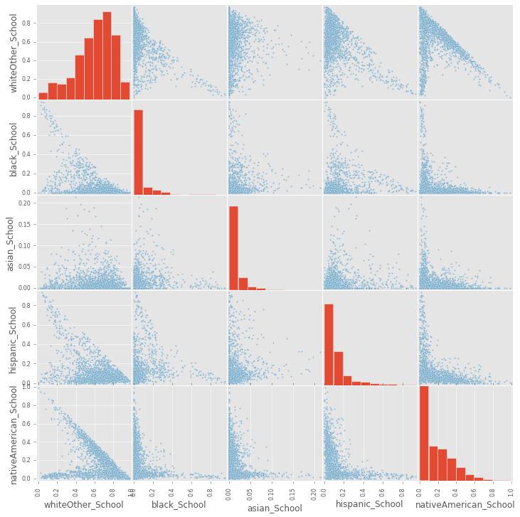

```python
demo_filter = selectedSchool2014[demographicAttributes]
scatter_matrix(demo_filter,figsize=(12,12),diagonal='hist')
```

### Coorelations for demographic attributes

The correlations also provide sufficient evidence of multicollinearity among the demographic variables, which confirms the need for principal component analysis.

```python
demoCorr = demo_filter.corr(method='pearson')
demoCorr
```

|  | whiteOther_School | black_School | asian_School | hispanic_School | nativeAmerican_School |
| --- | --- | --- | --- | --- | --- |
| whiteOther_School | 1.000000 | -0.518290 | -0.075467 | -0.488585 | -0.316483 |
| black_School | -0.518290 | 1.000000 | 0.125789 | 0.099656 | -0.290185 |
| asian_School | -0.075467 | 0.125789 | 1.000000 | 0.124785 | -0.257120 |
| hispanic_School | -0.488585 | 0.099656 | 0.124785 | 1.000000 | -0.411408 |
| nativeAmerican_School | -0.316483 | -0.290185 | -0.257120 | -0.411408 | 1.000000 |

### Descriptive for classrom attributes

```python
classSchool2014.describe()
```

|  | fallEnrollment_School | nonSpecialEdTeachersFTE_School | averageSalaryTeachers_School | advancedDegreeTeachers_School | yearsExperienceTeachers_School | studentsInSpecialEd_School | studentsInELL_School | specialEdTeachersFTE_School | freeReducedLunch_School |
| --- | --- | --- | --- | --- | --- | --- | --- | --- | --- |
| count | 1767.000000 | 1767.000000 | 1767.000000 | 1767.000000 | 1767.000000 | 1767.000000 | 1767.000000 | 1767.000000 | 1767.00000 |
| mean | 380.273911 | 20.993765 | 43812.698403 | 0.242418 | 12.470082 | 0.601939 | 0.055967 | 2.473520 | 0.65331 |
| std | 328.031585 | 15.524331 | 2770.166808 | 0.134082 | 3.408854 | 0.201694 | 0.110077 | 2.843986 | 0.21045 |
| min | 11.000000 | 2.110000 | 20555.750000 | 0.000000 | 0.976700 | 0.000000 | 0.000000 | 0.000000 | 0.00000 |
| 25% | 167.500000 | 10.713500 | 42026.240400 | 0.149500 | 10.156450 | 0.485100 | 0.000000 | 0.989000 | 0.51395 |
| 50% | 317.000000 | 17.857000 | 43580.253700 | 0.225200 | 12.439200 | 0.636400 | 0.015600 | 1.714000 | 0.66830 |
| 75% | 498.500000 | 26.711000 | 45416.199150 | 0.318350 | 14.603600 | 0.751400 | 0.052800 | 3.000000 | 0.80055 |
| max | 3336.000000 | 146.532000 | 64204.372400 | 1.000000 | 26.524200 | 0.974800 | 0.741900 | 27.394000 | 1.41460 |

### Scatterplots of classroom attributes

```
array([[<matplotlib.axes._subplots.AxesSubplot object at 0x000001DB4FCDBE48>,
        <matplotlib.axes._subplots.AxesSubplot object at 0x000001DB57581CF8>]], dtype=object)
```

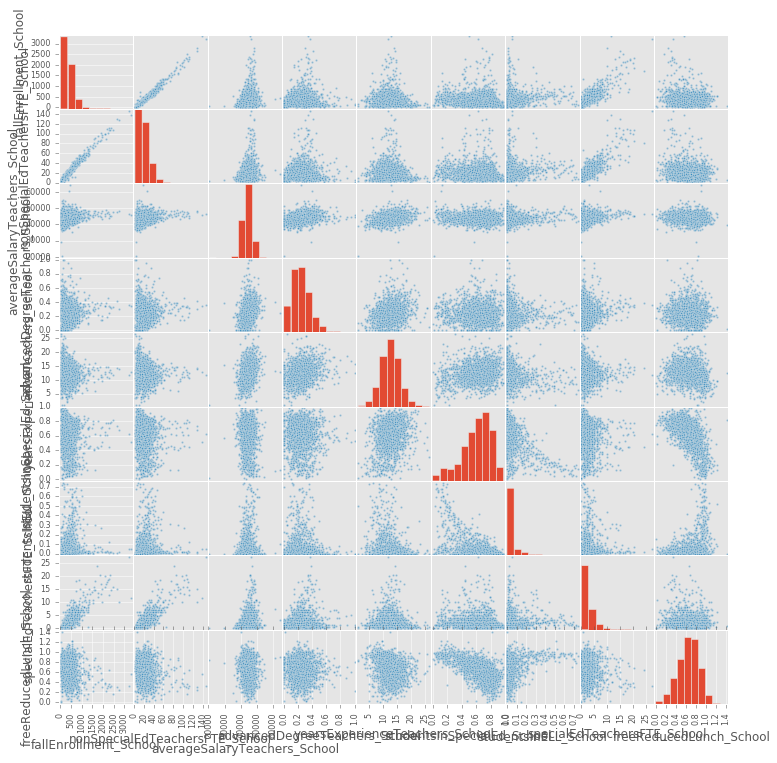

```python
class_filter = selectedSchool2014[classroomAttributes]
scatter_matrix(class_filter,figsize=(12,12),diagonal='hist')
```

### Coorelations for classroom attributes

```python
classCorr = class_filter.corr(method='pearson')
classCorr
```

|  | fallEnrollment_School | nonSpecialEdTeachersFTE_School | averageSalaryTeachers_School | advancedDegreeTeachers_School | yearsExperienceTeachers_School | studentsInSpecialEd_School | studentsInELL_School | specialEdTeachersFTE_School | freeReducedLunch_School |
| --- | --- | --- | --- | --- | --- | --- | --- | --- | --- |
| fallEnrollment_School | 1.000000 | 0.982325 | 0.214605 | 0.039316 | -0.115579 | -0.082169 | 0.155421 | 0.830418 | -0.186519 |
| nonSpecialEdTeachersFTE_School | 0.982325 | 1.000000 | 0.219074 | 0.049555 | -0.104475 | -0.093526 | 0.154667 | 0.824196 | -0.170220 |
| averageSalaryTeachers_School | 0.214605 | 0.219074 | 1.000000 | 0.329165 | 0.338787 | -0.123387 | 0.102219 | 0.242899 | -0.080446 |
| advancedDegreeTeachers_School | 0.039316 | 0.049555 | 0.329165 | 1.000000 | 0.256438 | -0.037178 | -0.056474 | 0.107382 | -0.038382 |
| yearsExperienceTeachers_School | -0.115579 | -0.104475 | 0.338787 | 0.256438 | 1.000000 | 0.212759 | -0.251419 | -0.061497 | -0.174377 |
| studentsInSpecialEd_School | -0.082169 | -0.093526 | -0.123387 | -0.037178 | 0.212759 | 1.000000 | -0.531834 | -0.101475 | -0.622897 |
| studentsInELL_School | 0.155421 | 0.154667 | 0.102219 | -0.056474 | -0.251419 | -0.531834 | 1.000000 | 0.072747 | 0.353948 |
| specialEdTeachersFTE_School | 0.830418 | 0.824196 | 0.242899 | 0.107382 | -0.061497 | -0.101475 | 0.072747 | 1.000000 | -0.111333 |
| freeReducedLunch_School | -0.186519 | -0.170220 | -0.080446 | -0.038382 | -0.174377 | -0.622897 | 0.353948 | -0.111333 | 1.000000 |

### Descriptive for administration attributes

```python
adminSchool2014.describe()
```

|  | counselorsFTE_School | otherProfessionalStaffFTE_School | administratorsFTE_School |
| --- | --- | --- | --- |
| count | 1767.000000 | 1767.000000 | 1767.000000 |
| mean | 0.892156 | 1.625178 | 1.441968 |
| std | 1.012229 | 1.644432 | 1.349362 |
| min | 0.000000 | 0.000000 | 0.000000 |
| 25% | 0.315000 | 0.494000 | 0.963000 |
| 50% | 0.667000 | 1.161000 | 1.000000 |
| 75% | 1.000000 | 2.284000 | 2.000000 |
| max | 9.000000 | 19.824000 | 17.257000 |

### Scatterplots of administration attributes

```
array([[<matplotlib.axes._subplots.AxesSubplot object at 0x000001DB5901C630>,
        <matplotlib.axes._subplots.AxesSubplot object at 0x000001DB5911D5C0>]], dtype=object)
```

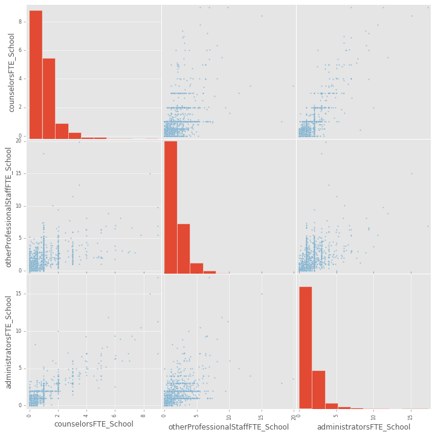

```python
admin_filter = selectedSchool2014[adminAttributes]
scatter_matrix(admin_filter,figsize=(12,12),diagonal='hist')
```

### Correlations of adminstration attributes

```python
adminCorr = admin_filter.corr(method='pearson')
adminCorr
```

|  | counselorsFTE_School | otherProfessionalStaffFTE_School | administratorsFTE_School |
| --- | --- | --- | --- |
| counselorsFTE_School | 1.000000 | 0.503750 | 0.825135 |
| otherProfessionalStaffFTE_School | 0.503750 | 1.000000 | 0.525903 |
| administratorsFTE_School | 0.825135 | 0.525903 | 1.000000 |

### Correlations among demographic attributes

The correlations provides sufficient evidence of multicollinearity among the demographic variables, which confirms the need for principal component analysis.

### PCA of demographic variables

```python
demographicAttributesNoLunches = ["whiteOther_School","black_School",
                                  "asian_School","hispanic_School",
                                  "nativeAmerican_School"]

toConvert = selectedSchool2014[demographicAttributesNoLunches]
converted = toConvert.as_matrix()
converted.shape
```

```
(1767, 5)
```

Using three PCA components to reduce the variable inflation on the demographic features due to high degree of multicollinearity between white, black and hispanic ethnicity

```python
#pca = decomposition.PCA(n_components='mle')
pca = decomposition.PCA(n_components=5)
pca.fit(converted)
```

```
PCA(copy=True, n_components=5, whiten=False)
```

### Components (results of PCA) from demographic variables

Transforming the 5 dimensional demographic data into 5 dimensional orthogonal(zero multicollinearity) data

```python
demoComponents = pca.transform(converted)
demoComponents.shape
#demoComponents
```

```
(1767, 5)
```

The first three components explain 99.4% variation in the school demography, the analysis proceed using the first three components

```python
print(pca.explained_variance_ratio_.cumsum())
```

```
[ 0.48482623  0.83265403  0.9944087   0.99999999  1.        ]
```

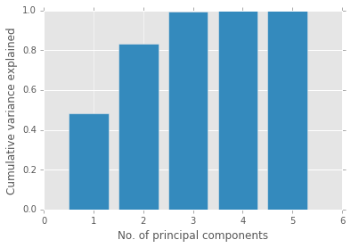

```python
plt.bar(np.arange(5)+.5,pca.explained_variance_ratio_.cumsum())
plt.ylim((0,1))
plt.xlabel('No. of principal components')
plt.ylabel('Cumulative variance explained')
plt.grid(axis = 'y', ls = '-', lw = 1, color = 'white')
```

### PC1 (high loading on number of WhiteOther students)

```
<Container object of 5 artists>
```

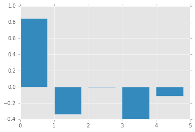

```python
plt.bar(np.arange(5),pca.components_[0])
```

The first principal component is highly loaded with white ethnicity

### PC2 (high loading on number of Native American students)

```
<Container object of 5 artists>
```

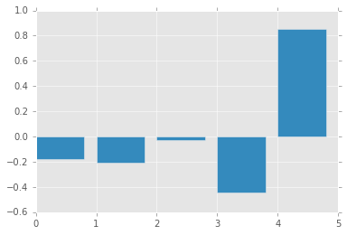

```python
plt.bar(np.arange(5),pca.components_[1])
```

The second principal component is highly loaded with native american ethnicity

### PC3 (low loading of Black students and high loading on number of Hispanic students)

```
<Container object of 5 artists>
```

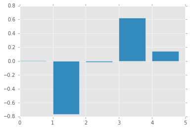

```python
plt.bar(np.arange(5),pca.components_[2])
```

The third principal component is loaded with black and hispanic ethnicity. It only explains 16% of demographic variation

```
<Container object of 5 artists>
```

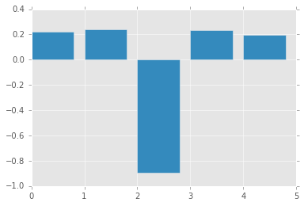

```python
plt.bar(np.arange(5),pca.components_[3])
```

```
<Container object of 5 artists>
```

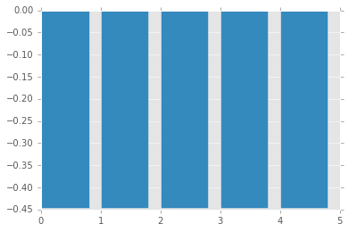

```python
plt.bar(np.arange(5),pca.components_[4])
```

### Convert components array to dataframe and select first the PCs

```python
df = pd.DataFrame(data=demoComponents)
componentNames = ["demo_pc1","demo_pc2","demo_pc3","demo_pc4","demo_pc4"]
df.columns = componentNames
selectedPCs = ["demo_pc1","demo_pc2","demo_pc3"]
df1 = df[selectedPCs]
df1.head()
```

|  | demo_pc1 | demo_pc2 | demo_pc3 |
| --- | --- | --- | --- |
| 0 | -0.138703 | 0.347719 | 0.063785 |
| 1 | -0.386699 | 0.623211 | 0.094876 |
| 2 | -0.430427 | 0.735886 | 0.084678 |
| 3 | -0.381781 | 0.717881 | 0.068178 |
| 4 | -0.498516 | 0.600102 | 0.075266 |

### Examine target feature: teacher experience

```python
teachExp = np.array(list(selectedSchool2014['yearsExperienceTeachers_School']))
print (teachExp.shape)
print ("min:" ,teachExp.min())
print ("mean:" ,teachExp.mean())
print ("max:" ,teachExp.max())
```

```
(1767,)
min: 0.9767
mean: 12.4700816638
max: 26.5242
```

### Merge PCA components with teacher experience feature and create binary value

```python
df1['teachExp_belowAverage'] = (selectedSchool2014['yearsExperienceTeachers_School']<teachExp.mean()).astype(int)
df1.head()
```

|  | demo_pc1 | demo_pc2 | demo_pc3 | teachExp_belowAverage |
| --- | --- | --- | --- | --- |
| 0 | -0.138703 | 0.347719 | 0.063785 | 0 |
| 1 | -0.386699 | 0.623211 | 0.094876 | 0 |
| 2 | -0.430427 | 0.735886 | 0.084678 | 0 |
| 3 | -0.381781 | 0.717881 | 0.068178 | 1 |
| 4 | -0.498516 | 0.600102 | 0.075266 | 1 |

## SVM and Logistic Regression Modeling

- [50 points] **Create a logistic regression model and a support vector machine model for the classification task involved with your dataset. Assess how well each model performs (use 80/20 training/testing split for your data). Adjust parameters of the models to make them more accurate. If your dataset size requires the use of stochastic gradient descent, then linear kernel only is fine to use.**
- [10 points] *Discuss the advantages of each model for each classification task. Does one type of model offer superior performance over another in terms of prediction accuracy? In terms of training time or efficiency? Explain in detail.*
- [30 points] *Use the weights from logistic regression to interpret the importance of different features for each classification task. Explain your interpretation in detail. Why do you think some variables are more important?*
- [10 points] *Look at the chosen support vectors for the classification task. Do these provide any insight into the data? Explain.*

### Training and testing set split

"... (use 80/20 training/testing split for your data."

```python
y = df1['teachExp_belowAverage'].values
del df1['teachExp_belowAverage']
X = df1.values

num_cv_iterations = 3
num_instances = len(y)
cv_object = ShuffleSplit(n=num_instances, n_iter=num_cv_iterations, test_size  = 0.2)

print (cv_object)
```

```
ShuffleSplit(1767, n_iter=3, test_size=0.2, random_state=None)
```

### Logistic regression

"Create a logistic regression model ..."

```python
lr_clf = LogisticRegression(penalty='l2', C=1, class_weight=None)
iter_num=0

logAccScores = []

for iter_num, (train_indices, test_indices) in enumerate(cv_object):
    lr_clf.fit(X[train_indices],y[train_indices])
    y_hat = lr_clf.predict(X[test_indices])
    conf = mt.confusion_matrix(y[test_indices],y_hat)
    #print conf[0,0] # TN
    #print conf[1,0] # FN
    #print conf[0,1] # FP
    #print conf[1,1] # TP
    acc = mt.accuracy_score(y[test_indices],y_hat)
    print ("====Iteration",iter_num+1," ====")
    print ('Accuracy:', acc) # Overall, how often is the classifier correct?
    logAccScores.append(acc)
    print ('Misclassification:', 1-acc)  #Overall, how often is it wrong?
    print ("Specificity:",conf[0,0]/float(conf[0,1]+conf[0,0])) # When it's actually no, how often does it predict no?
    print ("Precision:",conf[1,1]/float(conf[0,1]+conf[1,1])) # When it predicts yes, how often is it correct?
    print ("Confusion matrix:\n",(conf))
    print ("\n")
    print ("Average accuracy score:", sum(logAccScores)/len(logAccScores))
```

```
====Iteration 1  ====
Accuracy: 0.593220338983
Misclassification: 0.406779661017
Specificity: 0.727777777778
Precision: 0.6171875
Confusion matrix:
 [[131  49]
 [ 95  79]]


Average accuracy score: 0.593220338983
====Iteration 2  ====
Accuracy: 0.567796610169
Misclassification: 0.432203389831
Specificity: 0.715909090909
Precision: 0.6
Confusion matrix:
 [[126  50]
 [103  75]]


Average accuracy score: 0.580508474576
====Iteration 3  ====
Accuracy: 0.59604519774
Misclassification: 0.40395480226
Specificity: 0.747126436782
Precision: 0.648
Confusion matrix:
 [[130  44]
 [ 99  81]]


Average accuracy score: 0.585687382298
```

### Support Vector Machine model

*"Create ... a support vector model ..."*

```python
svm_clf = svm.SVC(kernel='linear',gamma='auto')
iter_num=0

svmAccScores = []

for iter_num, (train_indices, test_indices) in enumerate(cv_object):
    svm_clf.fit(X[train_indices],y[train_indices])
    y_hat = svm_clf.predict(X[test_indices])

    conf = mt.confusion_matrix(y[test_indices],y_hat)
    #print conf[0,0] # TN
    #print conf[1,0] # FN
    #print conf[0,1] # FP
    #print conf[1,1] # TP
    acc = mt.accuracy_score(y[test_indices],y_hat)
    print ("====Iteration",iter_num+1," ====")
    print ('Accuracy:', acc) # Overall, how often is the classifier correct?
    svmAccScores.append(acc)
    print ('Misclassification:', 1-acc)  #Overall, how often is it wrong?
    print ("Specificity:",conf[0,0]/float(conf[0,1]+conf[0,0])) # When it's actually no, how often does it predict no?
    print ("Precision:",conf[1,1]/float(conf[0,1]+conf[1,1])) # When it predicts yes, how often is it correct?
    #print "Confusion matrix:\n",(conf)
    print ("\n")
print ("Average accuracy score:", sum(svmAccScores)/len(svmAccScores))
```

```
====Iteration 1  ====
Accuracy: 0.641242937853
Misclassification: 0.358757062147
Specificity: 0.88829787234
Precision: 0.740740740741


====Iteration 2  ====
Accuracy: 0.564971751412
Misclassification: 0.435028248588
Specificity: 0.847058823529
Precision: 0.682926829268


====Iteration 3  ====
Accuracy: 0.601694915254
Misclassification: 0.398305084746
Specificity: 0.852631578947
Precision: 0.645569620253


Average accuracy score: 0.60263653484
```

### Adjust regression parameters

*"Adjust parameters of the models to make them more accurate"*

```python
lr_clf = LogisticRegression(penalty='l2', C=0.5, class_weight=None)
iter_num=0

logAccScores = []

for iter_num, (train_indices, test_indices) in enumerate(cv_object):
    lr_clf.fit(X[train_indices],y[train_indices])
    y_hat = lr_clf.predict(X[test_indices])
    conf = mt.confusion_matrix(y[test_indices],y_hat)
    #print conf[0,0] # TN
    #print conf[1,0] # FN
    #print conf[0,1] # FP
    #print conf[1,1] # TP
    acc = mt.accuracy_score(y[test_indices],y_hat)
    print ("====Iteration",iter_num+1," ====")
    print ('Accuracy:', acc) # Overall, how often is the classifier correct?
    logAccScores.append(acc)
    print ('Misclassification:', 1-acc)  #Overall, how often is it wrong?
    print ("Specificity:",conf[0,0]/float(conf[0,1]+conf[0,0])) # When it's actually no, how often does it predict no?
    print ("Precision:",conf[1,1]/float(conf[0,1]+conf[1,1])) # When it predicts yes, how often is it correct?
    print ("Confusion matrix:\n",(conf))
    print ("\n")
    print ("Average accuracy score:", sum(logAccScores)/len(logAccScores))
```

```
====Iteration 1  ====
Accuracy: 0.610169491525
Misclassification: 0.389830508475
Specificity: 0.790055248619
Precision: 0.657657657658
Confusion matrix:
 [[143  38]
 [100  73]]


Average accuracy score: 0.610169491525
====Iteration 2  ====
Accuracy: 0.635593220339
Misclassification: 0.364406779661
Specificity: 0.792134831461
Precision: 0.694214876033
Confusion matrix:
 [[141  37]
 [ 92  84]]


Average accuracy score: 0.622881355932
====Iteration 3  ====
Accuracy: 0.607344632768
Misclassification: 0.392655367232
Specificity: 0.779069767442
Precision: 0.680672268908
Confusion matrix:
 [[134  38]
 [101  81]]


Average accuracy score: 0.617702448211
```

## SVM and Logistic Regression Modeling

- [50 points] *Create a logistic regression model and a support vector machine model for the classification task involved with your dataset. Assess how well each model performs (use 80/20 training/testing split for your data). Adjust parameters of the models to make them more accurate. If your dataset size requires the use of stochastic gradient descent, then linear kernel only is fine to use.*
- [10 points] **Discuss the advantages of each model for each classification task. Does one type of model offer superior performance over another in terms of prediction accuracy? In terms of training time or efficiency? Explain in detail.**
- [30 points] *Use the weights from logistic regression to interpret the importance of different features for each classification task. Explain your interpretation in detail. Why do you think some variables are more important?*
- [10 points] *Look at the chosen support vectors for the classification task. Do these provide any insight into the data? Explain.*

### Discuss advantages of each model

*"Discuss the advantages of each model ..."*

The average accuracy score among the three shuffles between the logistic regression and support vector models for our features was about the same, i.e., they both tend to range from 58% to 61% accuracy.

Our models' predictions don't indicate that one technique is more advantageous than the other. The prediction acccuracy was similar for both.

The difference may be negligible because:

- Our question of interest is too focused
- The demographic variables may not be strong predictors of our target variable
- We are using so few features to predict our target variable
- Our data has thousands more instances than attributes
- etc

Documentation indicates that the data's characteristics/behavior can make one technique more advantageous than the other.

Source: http://scikit-learn.org/stable/modules/svm.html

## SVM and Logistic Regression Modeling

- [50 points] *Create a logistic regression model and a support vector machine model for the classification task involved with your dataset. Assess how well each model performs (use 80/20 training/testing split for your data). Adjust parameters of the models to make them more accurate. If your dataset size requires the use of stochastic gradient descent, then linear kernel only is fine to use.*
- [10 points] *Discuss the advantages of each model for each classification task. Does one type of model offer superior performance over another in terms of prediction accuracy? In terms of training time or efficiency? Explain in detail.*
- [30 points] **Use the weights from logistic regression to interpret the importance of different features for each classification task. Explain your interpretation in detail. Why do you think some variables are more important?**
- [10 points] *Look at the chosen support vectors for the classification task. Do these provide any insight into the data? Explain.*

### Plotting the regression weights

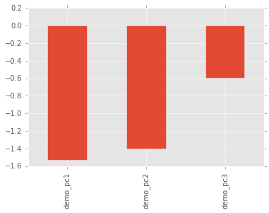

```python
weights = pd.Series(lr_clf.coef_[0],index=df1.columns)
weights.plot(kind='bar')
plt.show()
```

### Importance of weights

- Demo_pc1: The principal component with high whiteOther loading has a highest importance in classifying schools by teachers experience. However, this could simply reflect that there are more white students in Oklahoma's public schools. Adding federal "locale" factors my provide better differentiation among the target factor, i.e., city schools tend to have a more diverse student body than suburb, town and rural schools.
- Demo_pc2: The principal component with high Native American loading has nearly as high importance in classifying schools by teachers experience. However, this too could simply reflect that there are large numbers of Native American students in Oklahoma's public schools. Again, adding federal "locale" factors may provide better differentiation among the target factor.
- Demo_pc3: The principal components with low black & and high hispanic loading has the least importance in classifying schools by teacher experience. Again, adding federal "locale" factors my provide better differentiation among the target factor. Anecdotally, Oklahoma City and Tulsa—the state's largest city districts—have historically had high attrition rates and severe teacher shortages.

The combination of model predication accuracies and weights suggest that the diversity of a school's student body may be associated with teacher attrition rates; however these features may be confounding other more relevant factors. Identifiying those factors (e.g., teacher pay, locale, i.e., city, suburb, town, rural, student teacher ratio, etc,) may improve the ability to predict/identify schools at risk of higher attrition rates. More research is necessary.

## SVM and Logistic Regression Modeling

```python
# look at the support vectors
print(svm_clf.support_vectors_.shape)
print(svm_clf.support_.shape)
print(svm_clf.n_support_ )
print(svm_clf.support_.shape[0]/train_indices.shape[0])
```

```
(1235, 3)
(1235,)
[618 617]
0.8740268931351733
```